# Problem_Set_2_Yang

Author

Yang Han

Link to Github repository:

*https://github.com/Marslalala/ProblemSet2.git*

# Question 1

## Part a

- Create the function by using a loop over the die rolls.

```r
#'  Create the function by using a loop over the die rolls.
#'
#'  Identify cost, winning/losing rolling score and the single 6-sided die
#'  Generate the random rolling point by using function sample()
#'  Check the rolling point and give a score in each circumstance
#'  @param n an integer
#'  @return overall winning/losing money amount
play_dice_v1 <- function(n) {
  # Identify cost, winning/losing rolling score and the single 6-sided die
  score <- 0
  cost <- 2
  die <- c(1, 2, 3, 4, 5, 6)

  # Create the loop
  for(i in 1:n) {
    # Generate the random rolling point by using function sample()
    point <- sample(die, 1, replace = TRUE)
    # Check the rolling point and give a score in each circumstance
    if (point == 2) {
      score <- score - cost + 2
    } else if(point == 4) {
      score <- score - cost + 4
    } else if(point == 6) {
      score <- score - cost + 6
    } else {
      score <- score - cost
    }
  }

  return(score)
}
```

- Create the function by using built-in R vectorized functions.

```r
play_dice_v2 <- function(n) {
  #' Identify the cost and the single 6-sided die
  #'
  #' Generate the random rolling point by using function sample()
  #' Then calculate the score
  #' @param n an integer
  #' @return overall winning/losing money amount
  cost <- 2
  die <- c(1, 2, 3, 4, 5, 6)

  # Generate the random rolling point
  point <- sample(die, n, replace = TRUE)

  # Calculate the score
  score <- length(which(point == 2)) * 2 + length(which(point == 4)) * 4 + length(which(point == 6)) *
    6 - cost * n

  return(score)
}
```

- Create the function by collapsing the die rolls into a single table().

```r
play_dice_v3 <- function(n) {
  #' Identify the cost and the single 6-sided die
  #'
  #' Generate the random rolling point by using function sample()
  #' Collapsing the rolling points into a table to display the frequency of each roll point
  #' Using factor() to fix the indices of the table
  #' Finally, calculate the score
  #' @param n an integer
  #' @return overall winning/losing money amount
  cost <- 2
  die <- c(1, 2, 3, 4, 5, 6)

  # Generate the random rolling point by using function sample()
  point <- sample(die, n, replace = TRUE)

  # Collapsing the rolling points into a table
  freq_table <- table(factor(point, levels = 1:6))  # Using factor() to fix the indices of the table

  # Calculate the score
  score <- sum(freq_table[c(2, 4, 6)] * c(2, 4, 6)) - n * cost

  return(score)
}
```

- Create the function by using one of the “apply” functions.

```r
play_dice_v4 <- function(n) {
  #' Identify the cost and the single 6-sided die
  #'
  #' Generate the random rolling point by using function sample()
  #' Calculate the score by using an apply function
  #' @param n an integer
  #' @return overall winning/losing money amount
  cost <- 2
  die <- c(1, 2, 3, 4, 5, 6)

  # Generate the random rolling point by using function sample()
  point <- sample(die, n, replace = TRUE)
  point_l <- list(point)

  # Calculate the score
  score <- sapply(point_l, function(x) {
    return(length(which(x == 2)) * 2 + length(which(x == 4)) * 4 +
             length(which(x == 6)) * 6 - cost * n)

  })
  return(score)

}
```

## Part b

Run each examples for 5 times to prove the functions work.

```r
small_results <- c()
for (i in 1:5) {
  small_results <- c(small_results, play_dice_v1(3), play_dice_v2(3),
                     play_dice_v3(3), play_dice_v4(3))

}

large_results <- c()
for (i in 1:5) {
  large_results <- c(large_results, play_dice_v1(3000), play_dice_v2(3000),
                     play_dice_v3(3000), play_dice_v4(3000))
}

print(small_results)
```

```
 [1] -4 -6 -4  2  2  0 -6 -6 -2 -4 -6  2  2 -2 -6  2 -2  2 -6 -6
```

```r
print(large_results)
```

```
 [1] -228 -208 -106 -124  -36  -26 -268   52  130  142   94  -28   88  286  116
[16] -164   60   98   32  150
```

## Part c

Set a random seed and run each version few times to see whether the results are the same. First display the results for the input 3.

```r
s_m_results <- c()
set.seed(7)
for (i in 1:5) {
  s_m_results <- c(s_m_results, play_dice_v1(3))
}
set.seed(7)
for (i in 1:5) {
  s_m_results <- c(s_m_results, play_dice_v2(3))
}
set.seed(7)
for (i in 1:5) {
  s_m_results <- c(s_m_results, play_dice_v3(3))
}
set.seed(7)
for (i in 1:5) {
  s_m_results <- c(s_m_results, play_dice_v4(3))
}
small_matrix_results <- matrix(s_m_results, nrow = 5)
colnames(small_matrix_results) <- c('version 1', 'version 2', 'version 3', 'version 4')
print(small_matrix_results)
```

```
     version 1 version 2 version 3 version 4
[1,]         0         0         0         0
[2,]         4         4         4         4
[3,]         0         0         0         0
[4,]         0         0         0         0
[5,]         6         6         6         6
```

Now display the results for the input 3000.

```r
l_m_results <- c()
set.seed(7)
for (i in 1:5) {
  l_m_results <- c(l_m_results, play_dice_v1(3000))
}
set.seed(7)
for (i in 1:5) {
  l_m_results <- c(l_m_results, play_dice_v2(3000))
}
set.seed(7)
for (i in 1:5) {
  l_m_results <- c(l_m_results, play_dice_v3(3000))
}
set.seed(7)
for (i in 1:5) {
  l_m_results <- c(l_m_results, play_dice_v4(3000))
}
large_matrix_results <- matrix(l_m_results, nrow = 5)
colnames(large_matrix_results) <- c('version 1', 'version 2', 'version 3', 'version 4')
print(large_matrix_results)
```

```
     version 1 version 2 version 3 version 4
[1,]       -50       -50       -50       -50
[2,]       194       194       194       194
[3,]       158       158       158       158
[4,]      -180      -180      -180      -180
[5,]       -12       -12       -12       -12
```

We can see that both inputs give exactly the same results from a random seed.

## Part d

Install and load the package first, then run the function for 4 versions of my functions.

```r
library(microbenchmark)
microbenchmark(play_dice_v1(100), play_dice_v2(100),
               play_dice_v3(100), play_dice_v4(100))
```

```
Unit: microseconds
              expr     min       lq      mean   median       uq     max neval
 play_dice_v1(100) 293.702 298.3515 320.07611 301.2505 303.3010 645.900   100
 play_dice_v2(100)  12.301  13.8005  15.70690  14.8005  16.2010  32.600   100
 play_dice_v3(100) 142.701 147.5510 156.69493 150.7505 155.6510 302.201   100
 play_dice_v4(100)  22.701  25.7010  29.79895  29.6020  31.8515  60.601   100
```

When the input is low, using built-in vectorized functions is the fastest way, then is using apply(). the execution time of these two methods are closer compare with the other two methods. The slowest way is using a loop, which the execution time is far greater other methods.

```r
microbenchmark(play_dice_v1(10000), play_dice_v2(10000),
               play_dice_v3(10000), play_dice_v4(10000))
```

```
Unit: microseconds
                expr       min        lq      mean     median         uq
 play_dice_v1(10000) 30548.901 31694.951 33319.905 33328.6515 34087.5010
 play_dice_v2(10000)   630.801   643.701   665.855   650.3505   661.6505
 play_dice_v3(10000)  7386.301  7594.401  7827.609  7682.2515  7905.2505
 play_dice_v4(10000)   645.801   666.401   701.081   677.7010   697.2010
       max neval
 40285.901   100
   998.501   100
 12178.801   100
  1187.000   100
```

When the input is high, the rank of operation speed does not change, but the difference between collapsing a matrix and using a loop increases, which means, despite the inefficient of collapsing a matrix, it is at least better than using a loop.

## Part e

I believe this is a fair game. We can prove this by a Monte Carlo simulation. The expected value of income should equals zero, so that the game is fair. We can use a Monte Carlo simulation to check whether the expected amount of money is zero or very close to zero in the long run.

Set a trail first.

```r
trail <- c(rep.int(3000, 10000))
```

Run the version 2 function to obtain the simulation.

```r
sim <- sapply(trail, play_dice_v2)
```

Show the distribution we drew with a histogram

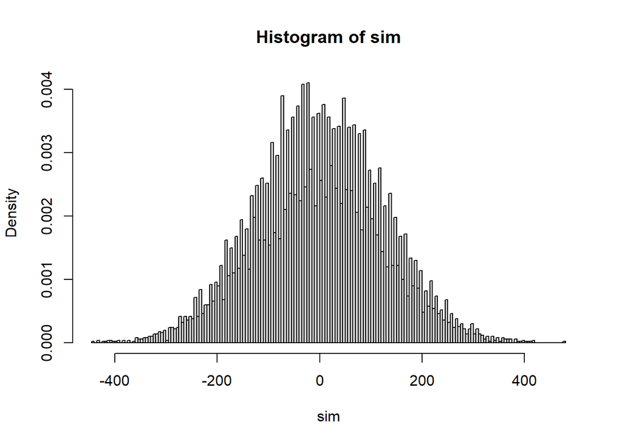

```r
hist(sim, breaks = 200, probability = TRUE)
```

By CLT, we can say that our simulation has a normal distribution with zero mean. We can see the pattern from the graph. Carry out an one-sample t-test to see whether the true mean is zero.

```r
t.test(sim)
```

```
    One Sample t-test

data:  sim
t = -0.52934, df = 9999, p-value = 0.5966
alternative hypothesis: true mean is not equal to 0
95 percent confidence interval:
 -3.121926  1.794326
sample estimates:
mean of x
  -0.6638
```

# Question2

## Part a

Load the data.

```r
car_data <- read.csv('cars.csv')
```

Rename the data.

```r
col_names <- c('dim_hei', 'dim_len', 'dim_wid', 'eng_driveline', 'eng_type', 'eng_hyb', 'eng_gearnum', 'eng_trans', 'fuel_city', 'fuel_type', 'fuel_highway', 'id_class', 'uid', 'id_make', 'id_myear', 'id_ryear', 'enstat_horsep', 'enstat_tor')
colnames(car_data) <- col_names
head(car_data)
```

```
  dim_hei dim_len dim_wid     eng_driveline
1     140     143     202   All-wheel drive
2     140     143     202 Front-wheel drive
3     140     143     202 Front-wheel drive
4     140     143     202   All-wheel drive
5     140     143     202   All-wheel drive
6      91      17      62   All-wheel drive
                                      eng_type eng_hyb eng_gearnum
1         Audi 3.2L 6 cylinder 250hp 236ft-lbs    True           6
2 Audi 2.0L 4 cylinder 200 hp 207 ft-lbs Turbo    True           6
3 Audi 2.0L 4 cylinder 200 hp 207 ft-lbs Turbo    True           6
4 Audi 2.0L 4 cylinder 200 hp 207 ft-lbs Turbo    True           6
5 Audi 2.0L 4 cylinder 200 hp 207 ft-lbs Turbo    True           6
6        Audi 3.2L 6 cylinder 265hp 243 ft-lbs    True           6
                       eng_trans fuel_city fuel_type fuel_highway
```

[output cut: 20 more lines]

## Part b

Modify the data to restrict the fuel type.

```r
car_gasoline <- car_data[car_data$fuel_type == 'Gasoline',]
```

## Part c

Fit the model by instructions and generate a summary of the model.

```r
car_gasoline$id_ryear <- as.factor(car_gasoline$id_ryear)
car_model <- lm(fuel_highway ~ enstat_horsep + enstat_tor + dim_hei + dim_len + dim_wid +
                id_ryear, data = car_gasoline)
summary(car_model)
```

```
Call:
lm(formula = fuel_highway ~ enstat_horsep + enstat_tor + dim_hei +
    dim_len + dim_wid + id_ryear, data = car_gasoline)

Residuals:
    Min      1Q  Median      3Q     Max
-10.824  -2.550  -0.452   2.372 202.639

Coefficients:
                Estimate Std. Error t value Pr(>|t|)
(Intercept)   32.2926630  0.7225982  44.690  < 2e-16 ***
enstat_horsep  0.0163556  0.0022772   7.182 7.96e-13 ***
enstat_tor    -0.0507425  0.0022030 -23.034  < 2e-16 ***
dim_hei        0.0099079  0.0011267   8.794  < 2e-16 ***
dim_len        0.0017290  0.0008836   1.957   0.0504 .
dim_wid       -0.0003343  0.0009045  -0.370   0.7117
id_ryear2010  -0.4539681  0.6768246  -0.671   0.5024
id_ryear2011   0.1711016  0.6757043   0.253   0.8001
id_ryear2012   1.3029279  0.6810076   1.913   0.0558 .
---
Signif. codes:  0 '***' 0.001 '**' 0.01 '*' 0.05 '.' 0.1 ' ' 1

Residual standard error: 4.602 on 4582 degrees of freedom
Multiple R-squared:  0.4192,    Adjusted R-squared:  0.4182
F-statistic: 413.3 on 8 and 4582 DF,  p-value: < 2.2e-16
```

When all other variables in the model held constant, we can see from the summary that the predictor horsepower is positively related with the MPG on the highway as the estimate of the coefficient is positive. To be more explicitly, as horsepower increases, MPG on the highway is expected to increase. The estimated coefficient is 0.016, which means when horsepower increases for 1 unit, the MPG on the highway would increase for 0.016. An important thing should be noticed, which is the value is for cars released in 2009(with this estimated intercept). When consider other releasing years, the estimated intercept might change in this model. The p-value for the estimated coefficient of horsepower is 7.96e-13 which is very small. This implies that this relationship between MPG on the highway and horsepower is statistically significant. They are very likely to have this positive relationship.

## Part d

Generate a new model with interactions between horsepower and torque, then give a summary.

```r
car_model2 <- lm(fuel_highway ~ enstat_horsep + enstat_tor + enstat_horsep:enstat_tor + dim_hei
                 + dim_len + dim_wid + id_ryear, data = car_gasoline)
summary(car_model2)
```

```
Call:
lm(formula = fuel_highway ~ enstat_horsep + enstat_tor + enstat_horsep:enstat_tor +
    dim_hei + dim_len + dim_wid + id_ryear, data = car_gasoline)

Residuals:
    Min      1Q  Median      3Q     Max
-11.109  -2.313  -0.258   2.062 203.540

Coefficients:
                           Estimate Std. Error t value Pr(>|t|)
(Intercept)               4.219e+01  7.930e-01  53.199  < 2e-16 ***
enstat_horsep            -1.666e-02  2.539e-03  -6.563 5.84e-11 ***
enstat_tor               -8.606e-02  2.533e-03 -33.972  < 2e-16 ***
dim_hei                   6.560e-03  1.070e-03   6.133 9.32e-10 ***
dim_len                   1.777e-03  8.318e-04   2.136   0.0327 *
dim_wid                  -1.169e-03  8.521e-04  -1.372   0.1700
id_ryear2010             -5.628e-01  6.372e-01  -0.883   0.3771
id_ryear2011              7.254e-02  6.361e-01   0.114   0.9092
id_ryear2012              1.197e+00  6.411e-01   1.867   0.0619 .
enstat_horsep:enstat_tor  1.124e-04  4.628e-06  24.276  < 2e-16 ***
---
Signif. codes:  0 '***' 0.001 '**' 0.01 '*' 0.05 '.' 0.1 ' ' 1

Residual standard error: 4.333 on 4581 degrees of freedom
Multiple R-squared:  0.4854,    Adjusted R-squared:  0.4844
F-statistic: 480.1 on 9 and 4581 DF,  p-value: < 2.2e-16
```

Firstly, plot histograms of horsepower and torque to determine which values we should choose for the interaction plot.

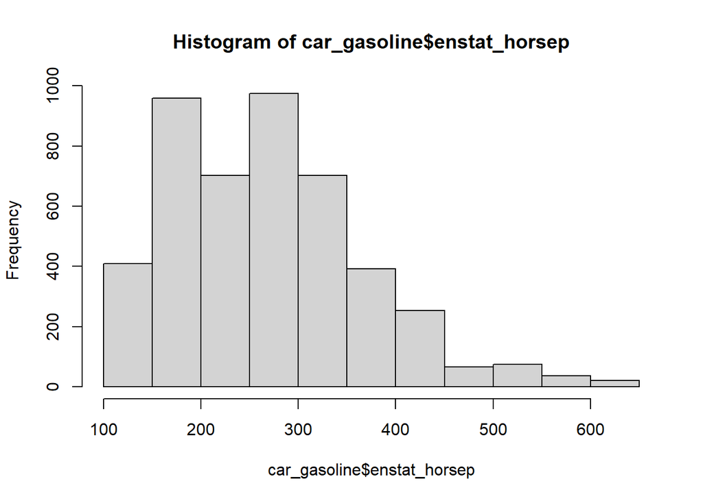

```r
hist(car_gasoline$enstat_horsep)
```

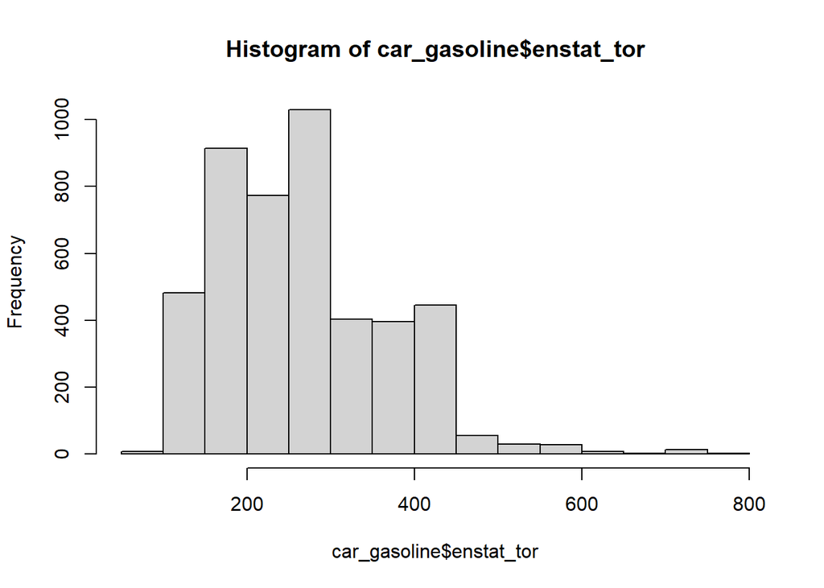

```r
hist(car_gasoline$enstat_tor)
```

From the graphs above , we know that both horsepower and torque are gathered from 100 to 450, so we can take values 100, 275 and 450.

```r
chosen_value <- c(100, 275, 450)
```

From the summary we can tell that there does have an interaction between horsepower and torque. Now generate an interaction plot to see the relationship.

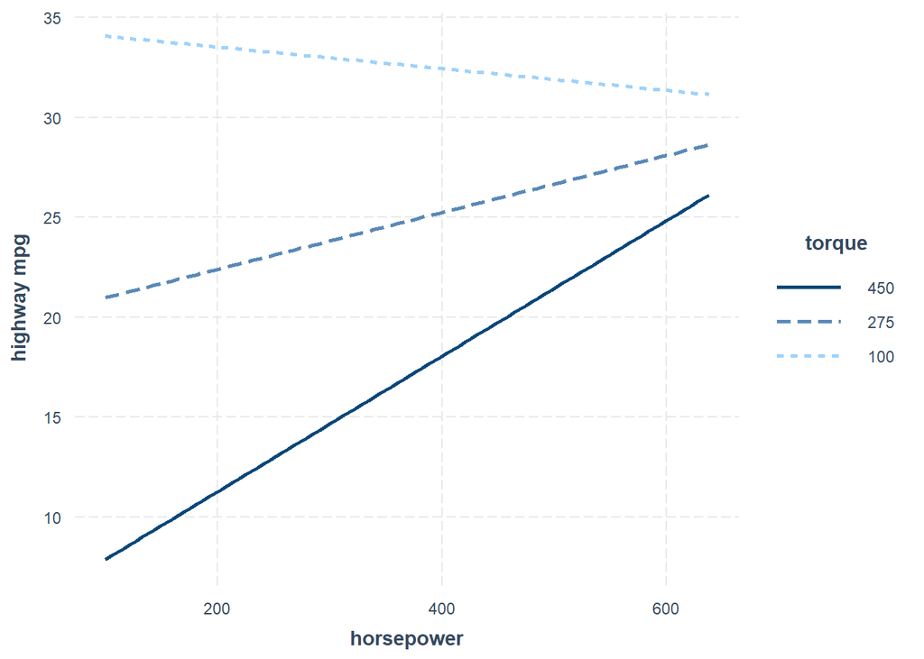

```r
library(interactions)
interact_plot(car_model2, pred = enstat_horsep, modx = enstat_tor, modx.values = chosen_value,
              data = car_gasoline, at = list(car_gasoline$id_ryear == 2010),
              x.label = 'horsepower', y.label = 'highway mpg', legend.main = 'torque')
```

## Part e

Design a matrix to calculate beta_hat and create response matrix.

```r
X <- model.matrix(fuel_highway ~ enstat_horsep * enstat_tor + enstat_horsep + enstat_tor +
                  dim_len + dim_wid + dim_hei + as.factor(id_ryear), data = car_gasoline)
Y <- car_gasoline$fuel_highway
```

Calculate the coefficient estimates manually.

```r
beta_hat <- solve(t(X) %*% X) %*% t(X) %*% Y
print(car_model2$coefficients)
```

```
             (Intercept)            enstat_horsep               enstat_tor
           42.1879478687            -0.0166633227            -0.0860592704
                 dim_hei                  dim_len                  dim_wid
            0.0065603903             0.0017767232            -0.0011694485
            id_ryear2010             id_ryear2011             id_ryear2012
           -0.5627857770             0.0725356431             1.1970329986
enstat_horsep:enstat_tor
            0.0001123567
```

```r
print(beta_hat)
```

```
                                  [,1]
(Intercept)              42.1879478687
enstat_horsep            -0.0166633227
enstat_tor               -0.0860592704
dim_len                   0.0017767232
dim_wid                  -0.0011694485
dim_hei                   0.0065603903
as.factor(id_ryear)2010  -0.5627857770
as.factor(id_ryear)2011   0.0725356431
as.factor(id_ryear)2012   1.1970329986
enstat_horsep:enstat_tor  0.0001123567
```

We can see the results are exactly the same as in the lm() given.

# Question 3

## Part a

. * Import the data first

. import delimited cars.csv

(encoding automatically selected: ISO-8859-1)

(18 vars, 5,076 obs)

. * Rename the variables

. rename dimensionsheight dim_hei

. rename dimensionslength dim_len

. rename dimensionswidth dim_wid

. rename engineinformationdriveline eng_driveline

. rename engineinformationenginetype eng_type

. rename engineinformationhybrid eng_hyb

. rename engineinformationnumberofforward eng_gearnum

. rename engineinformationtransmission eng_trans

. rename fuelinformationcitympg fuel_city

. rename fuelinformationfueltype fuel_type

. rename fuelinformationhighwaympg fuel_highway

. rename identificationclassification id_class

. rename identificationid uid

. rename identificationmake id_make

. rename identificationmodelyear id_myear

. rename identificationyear id_ryear

. rename engineinformationenginestatistic enstat_horsep

. rename v18 enstat_tor

.

.

## Part b

. * Create another data set which restrict the fuel_type to “Gasoline”

.

. keep if fuel_type == “Gasoline”

(485 observations deleted)

. save cars_gasoline

file cars_gasoline.dta saved

. browse

.

.

## Part c

* Fit the model by instructions

. regress fuel_highway enstat_horsep enstat_tor dim_hei dim_len dim_wid i.id_ryea

> r

Source | SS df MS Number of obs = 4,591

-------------+---------------------------------- F(8, 4582) = 413.35

Model | 70043.6695 8 8755.45869 Prob > F = 0.0000

Residual | 97055.298 4,582 21.1818634 R-squared = 0.4192

-------------+---------------------------------- Adj R-squared = 0.4182

Total | 167098.968 4,590 36.4050038 Root MSE = 4.6024

-------------------------------------------------------------------------------

fuel_highway | Coefficient Std. err. t P>|t| [95% conf. interval]

--------------+----------------------------------------------------------------

enstat_horsep | .0163556 .0022772 7.18 0.000 .0118913 .02082

enstat_tor | -.0507425 .002203 -23.03 0.000 -.0550614 -.0464236

dim_hei | .0099079 .0011267 8.79 0.000 .007699 .0121168

dim_len | .001729 .0008836 1.96 0.050 -3.36e-06 .0034613

dim_wid | -.0003343 .0009045 -0.37 0.712 -.0021075 .0014388

|

id_ryear |

2010 | -.4539681 .6768246 -0.67 0.502 -1.78087 .8729342

2011 | .1711016 .6757043 0.25 0.800 -1.153604 1.495808

2012 | 1.302928 .6810076 1.91 0.056 -.0321751 2.638031

|

_cons | 32.29266 .7225982 44.69 0.000 30.87602 33.7093

-------------------------------------------------------------------------------

. * When all other variables in the model held constant, we can see from the

. * summary that the predictor horsepower is positively related with the MPG on

. * the highway as the estimate of the coefficient is positive. To be more

. * explicitly, as horsepower increases, MPG on the highway is expected to

. * increase. The estimated coefficient is 0.016, which means when horsepower

. * increases for 1 unit, the MPG on the highway would increase for 0.016. An

. * important thing should be noticed, which is the value is for cars released i

> n

. * 2009(with this estimated intercept). When consider other releasing years,

. * the estimated intercept might change in this model. The p-value for the

. * estimated coefficient of horsepower is 7.96e-13 which is very small. This

. * implies that this relationship between MPG on the highway and horsepower is

. * statistically significant. They are very likely to have this positive

. * relationship.

.

.

## Part d

.

. * Generate a new model with interactions between horsepower and torque

. regress fuel_highway c.enstat_horsep##c.enstat_tor dim_hei dim_len dim_wid i.id

> _ryear

Source | SS df MS Number of obs = 4,591

-------------+---------------------------------- F(9, 4581) = 480.07

Model | 81105.8715 9 9011.76351 Prob > F = 0.0000

Residual | 85993.096 4,581 18.7716865 R-squared = 0.4854

-------------+---------------------------------- Adj R-squared = 0.4844

Total | 167098.968 4,590 36.4050038 Root MSE = 4.3326

--------------------------------------------------------------------------------

fuel_highway | Coefficient Std. err. t P>|t| [95% conf. interval]

---------------+----------------------------------------------------------------

enstat_horsep | -.0166633 .0025388 -6.56 0.000 -.0216406 -.011686

enstat_tor | -.0860593 .0025333 -33.97 0.000 -.0910257 -.0810928

|

3. |

enstat_horsep#|

c.enstat_tor | .0001124 4.63e-06 24.28 0.000 .0001033 .0001214

|

dim_hei | .0065604 .0010696 6.13 0.000 .0044634 .0086573

dim_len | .0017767 .0008318 2.14 0.033 .0001459 .0034075

dim_wid | -.0011694 .0008521 -1.37 0.170 -.00284 .0005011

|

id_ryear |

2010 | -.5627858 .6371716 -0.88 0.377 -1.811949 .6863777

2011 | .0725356 .6361142 0.11 0.909 -1.174555 1.319626

2012 | 1.197033 .6411085 1.87 0.062 -.0598488 2.453915

|

_cons | 42.18795 .7930274 53.20 0.000 40.63323 43.74266

--------------------------------------------------------------------------------

. * Now choose values for horsepower and torque

. global lower = 100

. global median = 275

. global higher = 450

. * Then draw the interaction plot

. margins, at(enstat_horsep=(100(3)450) enstat_tor=($lower, $median, $higher))

Predictive margins Number of obs = 4,591

Model VCE: OLS

Expression: Linear prediction, predict()

1._at: enstat_horsep = 100

enstat_tor = 100

2._at: enstat_horsep = 100

enstat_tor = 275

, … ,

350._at: enstat_horsep = 448

enstat_tor = 275

351._at: enstat_horsep = 448

enstat_tor = 450

------------------------------------------------------------------------------

| Delta-method

| Margin std. err. t P>|t| [95% conf. interval]

-------------+----------------------------------------------------------------

_at |

1 | 34.19066 .1923479 177.75 0.000 33.81356 34.56775

2 | 21.09653 .3810067 55.37 0.000 20.34957 21.84348

3 | 8.002395 .7596302 10.53 0.000 6.513154 9.491636

4 | 34.17437 .1894697 180.37 0.000 33.80292 34.54582

5 | 21.13923 .3747112 56.41 0.000 20.40461 21.87384

, … ,

347 | 26.00752 .3757288 69.22 0.000 25.27091 26.74413

348 | 19.69693 .1425787 138.15 0.000 19.4174 19.97645

349 | 32.30183 .746948 43.25 0.000 30.83745 33.76621

350 | 26.05022 .3820249 68.19 0.000 25.30127 26.79918

351 | 19.79862 .144328 137.18 0.000 19.51567 20.08157

------------------------------------------------------------------------------

. marginsplot

Variables that uniquely identify margins: enstat_horsep enstat_tor

.

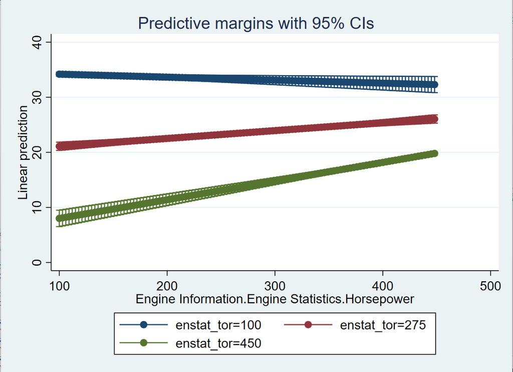